# Health-Related Social Influence Strategies in Overweight Romantic Couples: Daily Associations with Physical Activity and Affect for Targets and Actors

Pascal Küng, MSc (ORCID: 0000-0001-7346-9414), Corina Berli, PhD (ORCID: 0000-0002-5078-3539), Patrick S. Höhener, MSc (ORCID: 0000-0003-3635-2799), Robert Tobias, PhD (ORCID: 0000-0001-7972-122X), Urte Scholz, PhD (ORCID: 0000-0003-0184-5921)

2024-10-26

# Setup and loading

```r
df$CoupleID <- as.factor(df$CoupleID)

# Subsetting only the target person.
df <- df[(df["sbyz_p"] == 1), ]
```

# Describe sample

## Target’s health

```r
# Add PA risk assessment to df

df_baseline_target <- df_baseline_target %>%
  mutate(
    parq_score = rowMeans(across(c(sb0prq01, sb0prq02, sb0prq03, sb0prq04, sb0prq05, sb0prq06, sb0prq08)), na.rm = TRUE),
    n_health_issues = rowSums(across(c(sb0prq01, sb0prq02, sb0prq03, sb0prq04, sb0prq05, sb0prq06, sb0prq08)), na.rm = TRUE),
    has_zero_issues = as.factor(ifelse(n_health_issues == 0, 1, 0)),
    has_heart_condition = as.factor(sb0prq01),
    has_chest_pain = as.factor(sb0prq02),
    has_breathing_issues = as.factor(sb0prq03),
    has_dizziness_or_fainting = as.factor(sb0prq04),
    has_joint_or_bone_problems = as.factor(sb0prq05),
    takes_heart_medications = as.factor(sb0prq06),
    has_other_health_issues = as.factor(sb0prq08),
    other_health_issue = as.character(sb0prq07),
    other_health_issue = as.factor(ifelse(
      other_health_issue %in% c('faulheit', 'Keine Motivation (Faulheit)', 'Zeitmangel', 'Übergewicht', 'übergewicht'),
      NA, other_health_issue)),
    has_diabetes = as.factor(sb0prq09)
  ) %>%
  dplyr::select(parq_score, n_health_issues, has_zero_issues, has_heart_condition, has_chest_pain,
         has_breathing_issues, has_dizziness_or_fainting, has_joint_or_bone_problems,
         takes_heart_medications, has_diabetes, has_other_health_issues, other_health_issue)


a <- as.data.frame(report::report_table(df_baseline_target)[, c('Variable', 'Level', 'n_Obs', 'percentage_Obs', 'Mean', 'SD', 'Min', 'Max')])

a[a$Level != 0,]
```

|  | Variable | Level | n_Obs | percentage_Obs | Mean | SD | Min | Max |
| --- | --- | --- | --- | --- | --- | --- | --- | --- |
| NA | NA | NA | NA | NA | NA | NA | NA | NA |
| NA.1 | NA | NA | NA | NA | NA | NA | NA | NA |
| 15 | has_zero_issues | 1 | 30 | 30.303030 | NA | NA | NA | NA |
| 9 | has_heart_condition | 1 | 6 | 6.060606 | NA | NA | NA | NA |
| 10 | has_chest_pain | 1 | 7 | 7.070707 | NA | NA | NA | NA |
| 13 | has_breathing_issues | 1 | 15 | 15.151515 | NA | NA | NA | NA |
| 12 | has_dizziness_or_fainting | 1 | 12 | 12.121212 | NA | NA | NA | NA |
| 14 | has_joint_or_bone_problems | 1 | 27 | 27.272727 | NA | NA | NA | NA |
| 16 | takes_heart_medications | 1 | 35 | 35.353535 | NA | NA | NA | NA |
| 8 | has_diabetes | 1 | 6 | 6.060606 | NA | NA | NA | NA |
| 7 | has_other_health_issues | missing | 2 | 2.020202 | NA | NA | NA | NA |
| 11 | has_other_health_issues | 1 | 10 | 10.101010 | NA | NA | NA | NA |
| 1 | other_health_issue | Asthma | 1 | 1.010101 | NA | NA | NA | NA |
| 2 | other_health_issue | chronisches Schmerzsyndrom | 1 | 1.010101 | NA | NA | NA | NA |
| 3 | other_health_issue | Kniebeschwerden | 1 | 1.010101 | NA | NA | NA | NA |
| 4 | other_health_issue | Morbus Parkinson | 1 | 1.010101 | NA | NA | NA | NA |
| 5 | other_health_issue | rückenprobleme | 1 | 1.010101 | NA | NA | NA | NA |
| 6 | other_health_issue | Stressinkontinenz | 1 | 1.010101 | NA | NA | NA | NA |
| 26 | other_health_issue | missing | 93 | 93.939394 | NA | NA | NA | NA |

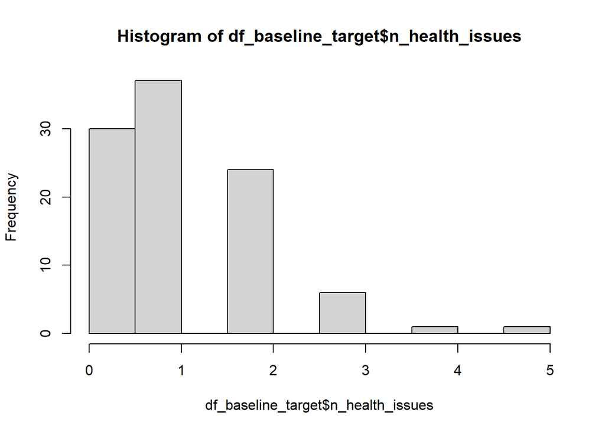

```r
hist(df_baseline_target$n_health_issues)
```

## Agent’s health

```r
# Add PA risk assessment to df

df_baseline_agent <- df_baseline_agent %>%
  mutate(
    parq_score = rowMeans(across(c(pb0prq01, pb0prq02, pb0prq03, pb0prq04, pb0prq05, pb0prq06, pb0prq08)), na.rm = TRUE),
    n_health_issues = rowSums(across(c(pb0prq01, pb0prq02, pb0prq03, pb0prq04, pb0prq05, pb0prq06, pb0prq08)), na.rm = TRUE),
    has_zero_issues = as.factor(ifelse(n_health_issues == 0, 1, 0)),
    has_heart_condition = as.factor(pb0prq01),
    has_chest_pain = as.factor(pb0prq02),
    has_breathing_issues = as.factor(pb0prq03),
    has_dizziness_or_fainting = as.factor(pb0prq04),
    has_joint_or_bone_problems = as.factor(pb0prq05),
    takes_heart_medications = as.factor(pb0prq06),
    has_other_health_issues = as.factor(pb0prq08),
    other_health_issue = as.character(pb0prq07),
    other_health_issue = as.factor(ifelse(
      other_health_issue %in% c('faulheit', 'Keine Motivation (Faulheit)', 'Zeitmangel', 'Übergewicht', 'übergewicht'),
      NA, other_health_issue)),
    has_diabetes = as.factor(pb0prq09))  %>%
  dplyr::select(parq_score, n_health_issues, has_zero_issues, has_heart_condition, has_chest_pain,
       has_breathing_issues, has_dizziness_or_fainting, has_joint_or_bone_problems,
       takes_heart_medications, has_diabetes, has_other_health_issues, other_health_issue)


b <- as.data.frame(report::report_table(df_baseline_agent)[, c('Variable', 'Level', 'n_Obs', 'percentage_Obs', 'Mean', 'SD', 'Min', 'Max')])


b[b$Level != 0,]
```

|  | Variable | Level | n_Obs | percentage_Obs | Mean | SD | Min | Max |
| --- | --- | --- | --- | --- | --- | --- | --- | --- |
| NA | NA | NA | NA | NA | NA | NA | NA | NA |
| NA.1 | NA | NA | NA | NA | NA | NA | NA | NA |
| 15 | has_zero_issues | 1 | 31 | 31.313131 | NA | NA | NA | NA |
| 7 | has_heart_condition | 1 | 2 | 2.020202 | NA | NA | NA | NA |
| 9 | has_chest_pain | 1 | 4 | 4.040404 | NA | NA | NA | NA |
| 13 | has_breathing_issues | 1 | 24 | 24.242424 | NA | NA | NA | NA |
| 12 | has_dizziness_or_fainting | 1 | 15 | 15.151515 | NA | NA | NA | NA |
| 16 | has_joint_or_bone_problems | 1 | 33 | 33.333333 | NA | NA | NA | NA |
| 14 | takes_heart_medications | 1 | 25 | 25.252525 | NA | NA | NA | NA |
| 10 | has_diabetes | 1 | 7 | 7.070707 | NA | NA | NA | NA |
| 8 | has_other_health_issues | missing | 3 | 3.030303 | NA | NA | NA | NA |
| 11 | has_other_health_issues | 1 | 9 | 9.090909 | NA | NA | NA | NA |
| 1 | other_health_issue |  | 1 | 1.010101 | NA | NA | NA | NA |
| 2 | other_health_issue | aktuell akute Schmerzen im Lumbago (gemäss Physioverordnung) | 1 | 1.010101 | NA | NA | NA | NA |
| 3 | other_health_issue | Eingeschränkt durch MS | 1 | 1.010101 | NA | NA | NA | NA |
| 4 | other_health_issue | Knieprothese | 1 | 1.010101 | NA | NA | NA | NA |
| 5 | other_health_issue | Multiple Sklerose | 1 | 1.010101 | NA | NA | NA | NA |
| 6 | other_health_issue | Rheumatisches Arthritis, | 1 | 1.010101 | NA | NA | NA | NA |
| 24 | other_health_issue | missing | 93 | 93.939394 | NA | NA | NA | NA |

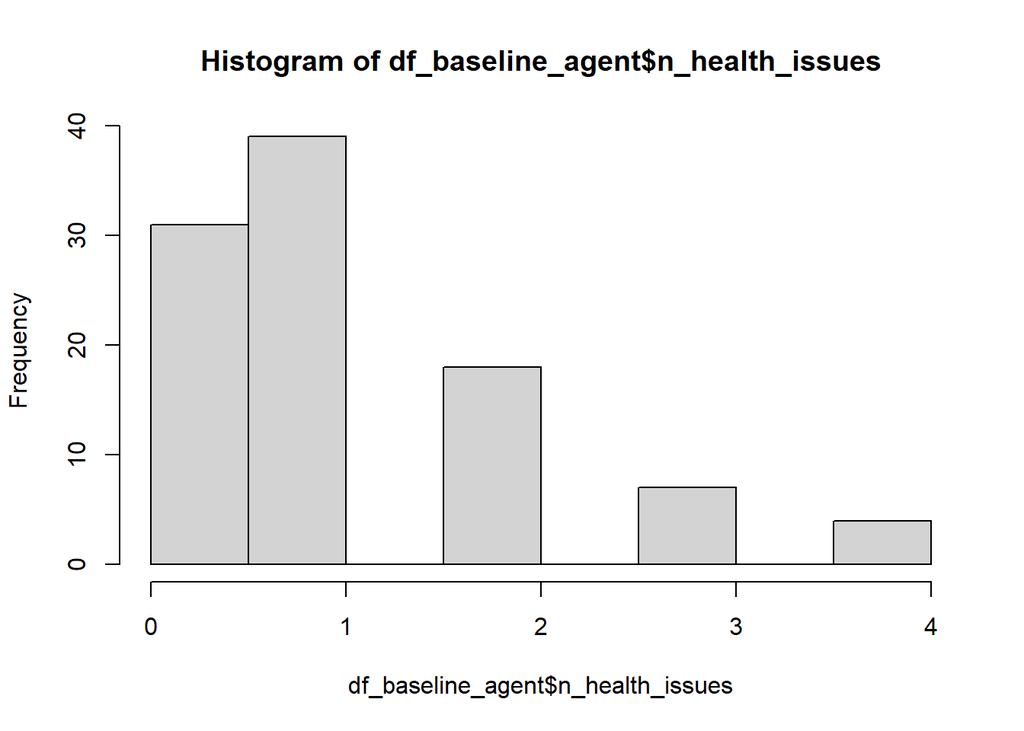

```r
hist(df_baseline_agent$n_health_issues)
```

## Joint health

```r
# Add PA risk assessment to df

df_baseline_joint <- rbind(df_baseline_target, df_baseline_agent)


c <- as.data.frame(report::report_table(df_baseline_joint)[, c('Variable', 'Level', 'n_Obs', 'percentage_Obs', 'Mean', 'SD', 'Min', 'Max')])

c[c$Level != 0,]
```

|  | Variable | Level | n_Obs | percentage_Obs | Mean | SD | Min | Max |
| --- | --- | --- | --- | --- | --- | --- | --- | --- |
| NA | NA | NA | NA | NA | NA | NA | NA | NA |
| NA.1 | NA | NA | NA | NA | NA | NA | NA | NA |
| 22 | has_zero_issues | 1 | 61 | 30.8080808 | NA | NA | NA | NA |
| 14 | has_heart_condition | 1 | 8 | 4.0404040 | NA | NA | NA | NA |
| 15 | has_chest_pain | 1 | 11 | 5.5555556 | NA | NA | NA | NA |
| 19 | has_breathing_issues | 1 | 39 | 19.6969697 | NA | NA | NA | NA |
| 18 | has_dizziness_or_fainting | 1 | 27 | 13.6363636 | NA | NA | NA | NA |
| 20 | has_joint_or_bone_problems | 1 | 60 | 30.3030303 | NA | NA | NA | NA |
| 21 | takes_heart_medications | 1 | 60 | 30.3030303 | NA | NA | NA | NA |
| 16 | has_diabetes | 1 | 13 | 6.5656566 | NA | NA | NA | NA |
| 13 | has_other_health_issues | missing | 5 | 2.5252525 | NA | NA | NA | NA |
| 17 | has_other_health_issues | 1 | 19 | 9.5959596 | NA | NA | NA | NA |
| 1 | other_health_issue | Asthma | 1 | 0.5050505 | NA | NA | NA | NA |
| 2 | other_health_issue | chronisches Schmerzsyndrom | 1 | 0.5050505 | NA | NA | NA | NA |
| 3 | other_health_issue | Kniebeschwerden | 1 | 0.5050505 | NA | NA | NA | NA |
| 4 | other_health_issue | Morbus Parkinson | 1 | 0.5050505 | NA | NA | NA | NA |
| 5 | other_health_issue | rückenprobleme | 1 | 0.5050505 | NA | NA | NA | NA |
| 6 | other_health_issue | Stressinkontinenz | 1 | 0.5050505 | NA | NA | NA | NA |
| 7 | other_health_issue |  | 1 | 0.5050505 | NA | NA | NA | NA |
| 8 | other_health_issue | aktuell akute Schmerzen im Lumbago (gemäss Physioverordnung) | 1 | 0.5050505 | NA | NA | NA | NA |
| 9 | other_health_issue | Eingeschränkt durch MS | 1 | 0.5050505 | NA | NA | NA | NA |
| 10 | other_health_issue | Knieprothese | 1 | 0.5050505 | NA | NA | NA | NA |
| 11 | other_health_issue | Multiple Sklerose | 1 | 0.5050505 | NA | NA | NA | NA |
| 12 | other_health_issue | Rheumatisches Arthritis, | 1 | 0.5050505 | NA | NA | NA | NA |
| 30 | other_health_issue | missing | 186 | 93.9393939 | NA | NA | NA | NA |

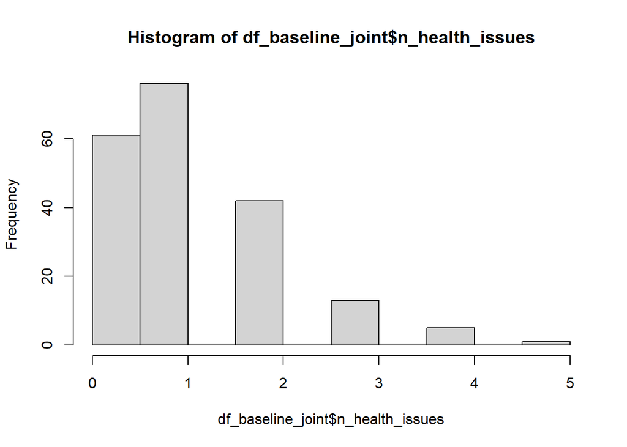

```r
hist(df_baseline_joint$n_health_issues)
```

## Other sample Statistics

```r
infodf <- df[,c('sb0sex01', 'pb0sex01',
      'group', #group 1 + 2 = EG, 3 + 4 = KG
      'sb0age01', 'pb0age01',
      'sb0edu01', 'pb0edu01', # welchen höchsten Bildungsabschluss haben Sie?
      'sb0aus01', 'pb0aus01', # Was ist ihre Berufsausbildung?
      'sb0occ01', 'pb0occ01', # Sie sind zur Zeit? (occupation)
      'sb0bez_r', # Dauer Beziehung in Jahren
      'sb0woh_r', # Dauer zusammen wohnen in Monaten
      'sb0ziv01', #verheiratet?
      'sb0kid01', # Kinder mit derzeitigem Parnter?
      'sb0kiz01', # wie viele Kinder?
      'sb0kih01', # Lebt min. 1 Kind in Haushalt?
      'sb0net01', # Monatliches Netto Einkommen des Haushalts
      'sb0bmi', # bmi target
      'pb0bmi', # bmi agent
      'sb0matur', # matura target
      'pb0matur' # matura agent
      )]

infodf$sb0woh_r <- infodf$sb0woh_r / 12

infodfunlabelled <- infodf %>%
  mutate(across(where(is.labelled), as_factor)) %>%
  as.data.frame(report_ta)

sample_df <- as.data.frame(report_table(infodfunlabelled))

# export to excel

writexl::write_xlsx(sample_df, "o1_SampleDescription.xlsx")
```

```r
# Date of diary days
range(df$sbwdat01, na.rm = T)
```

```
## [1] "2012-10-13" "2014-06-13"
```

# Data wrangling

## Calculating Scores

```r
# Function to compute within- and between- omega
omega_multilevel <- function(data, variables, cluster_var = "CoupleID", fiml = TRUE, ci = 0.95) {
  #' This function computes omega reliability coefficients for multilevel data.
  #' It fits a two-level CFA model using lavaan and calculates omega coefficients for both within-cluster and between-cluster levels.
  #'
  #' Inputs:
  #' - data: A data frame containing the variables for analysis.
  #' - variables: A character vector of variable names to include in the model.
  #' - cluster_var: Name of the clustering variable (default: "CoupleID").
  #' - fiml: If TRUE, uses Full Information Maximum Likelihood for missing data (default: TRUE).
  #' - ci: Confidence level for intervals (default: 0.95).
  #'
  #' Returns a list containing:
  #' - omegas: Data frame with omega estimates, standard errors, and confidence intervals.
  #' - fit_indices: Model fit indices (chi-square, df, p-value, CFI, TLI, RMSEA, SRMR).
  #' - model: The lavaan model specification.
  #' - full_summary: Full summary output from the lavaan model.
  #'
  #' The function uses robust maximum likelihood estimation (MLR) and computes confidence intervals using the delta method.
  #' At least two variables are required for the model.
  # Error checking
  if(length(variables) < 2) {
    stop("At least two variables are required for the model.")
  }

  # Create the model string
  model_parts <- lapply(seq_along(variables), function(i) {
    var <- variables[i]
    c(
      sprintf("f_within =~ wl%d*%s", i, var),
      sprintf("%s ~~ wr%d*%s", var, i, var),
      sprintf("f_between =~ bl%d*%s", i, var),
      sprintf("%s ~ 1", var),
      sprintf("%s ~~ br%d*%s", var, i, var),
      sprintf("wr%d > 0", i),
      sprintf("br%d > 0", i)
    )
  })

  model <- c(
    "# Within level",
    "level: 1",
    unlist(lapply(model_parts, `[`, 1:2)),
    "",
    "# Between level",
    "level: 2",
    unlist(lapply(model_parts, `[`, 3:5)),
    "",
    "# Defined parameters for omega calculation",
    sprintf("num_within := (%s)^2", paste0("wl", seq_along(variables), collapse = " + ")),
    sprintf("denom_within := (%s)^2 + (%s)",
            paste0("wl", seq_along(variables), collapse = " + "),
            paste0("wr", seq_along(variables), collapse = " + ")),
    "omega_within := num_within / denom_within",
    "",
    sprintf("num_between := (%s)^2", paste0("bl", seq_along(variables), collapse = " + ")),
    sprintf("denom_between := (%s)^2 + (%s)",
            paste0("bl", seq_along(variables), collapse = " + "),
            paste0("br", seq_along(variables), collapse = " + ")),
    "omega_between := num_between / denom_between",
    "",
    "# Constraints",
    unlist(lapply(model_parts, `[`, 6:7))
  )

  model <- paste(model, collapse = "\n")

  # Fit the model
  fit <- tryCatch({
    lavaan::sem(
      model,
      data = data,
      cluster = cluster_var,
      estimator = "MLR",
      missing = if(fiml) "fiml" else "listwise",
      std.lv = TRUE,
      auto.fix.first = FALSE,
      auto.var = FALSE,
      se = "robust"
    )
  }, error = function(e) {
    stop("Error in fitting the model: ", e$message)
  })

  # Extract results
  summary_fit <- summary(fit)
  omegas <- summary_fit$pe[summary_fit$pe$label %in% c('omega_within', 'omega_between'), ]

  # Calculate confidence intervals
  z_score <- qnorm((1 + ci) / 2)
  omegas$ci.lower <- omegas$est - z_score * omegas$se
  omegas$ci.upper <- omegas$est + z_score * omegas$se

  # Select relevant columns
  omegas <- omegas[, c('label', 'est', 'se', 'ci.lower', 'ci.upper')]
  rownames(omegas) <- omegas$label
  omegas$label <- NULL

  # Ensure CI bounds are within [0, 1]
  omegas$ci.lower <- pmax(0, pmin(1, omegas$ci.lower))
  omegas$ci.upper <- pmax(0, pmin(1, omegas$ci.upper))

  fit_indices <- fitMeasures(fit, c("chisq", "df", "pvalue", "cfi", "tli", "rmsea", "srmr"))

  # Return results
  list(
    omegas = omegas,
    fit_indices = fit_indices,
    model = model,
    full_summary = summary_fit
  )
}
```

Calculating Scores by taking the mean of the applicable items. “target” is the person that receives control. - “agent” is the person that uses control (but also support)

```r
# Predictors
df$PSC_agent <- (df$ppysko06 + df$ppysko09 + df$ppysko21 + df$ppysko25) / 4
df$NSC_agent <- (df$ppysko03 + df$ppysko11 + df$ppysko26 + df$ppysko29) / 4

# Outcomes
df$Paff_agent <- (df$pbypan03 + df$pbypan14 + df$pbypan09 + df$pbypan12 + df$pbypan16) / 5
df$Naff_agent <- (df$pbypan02 + df$pbypan04 + df$pbypan07 + df$pbypan15 + df$pbypan19) / 5

df$Paff_target <- (df$sbypan03 + df$sbypan14 + df$sbypan09 + df$sbypan12 + df$sbypan16) / 5
df$Naff_target <- (df$sbypan02 + df$sbypan04 + df$sbypan07 + df$sbypan15 + df$sbypan19) / 5

# Covariates
## Social Support
df$Sup_target <- (df$sbysug99 + df$sbysug98) / 2
df$Sup_agent <- (df$pbysug99 + df$pbysug98) / 2


# preparing covariates for sensitivity Analysis
# mean for time spent together from each partners report.
df$time_spent <- df$sbytim99 + df$pbytim99 / 2
# renaming variables that have to be centered
df <- transform(df,
                reldur = sb0bez_r,
                sage = sb0age01,
                page = pb0age01,
                sbmi = sb0bmi,
                pbmi = pb0bmi
                )


# Filtering out days with low wear compliance
df <- df %>%
  mutate(sbwmvpa01 = ifelse(sbwwear > 10, sbwmvpa01, NA),
         pbwmvpa01 = ifelse(pbwwear > 10, pbwmvpa01, NA)
         )

head(df)
```

| ID | CoupleID | group | sbyz_p | idzp | idsex | male | female | sbyday | sbyday1to14 | idzpday | sbyidday | sb0idrun | sb0sex01 | sb0age01 | sb0edu01 | sb0aus01 | sb0aus02 | sb0occ01 | sb0occ02 | sb0kg01 | sb0kg02 | sb0cm01 | sb0cm02 | sb0bez01 | sb0bez02 | sb0woh01 | sb0woh02 | sb0ziv01 | sb0tim01 | … |
| --- | --- | --- | --- | --- | --- | --- | --- | --- | --- | --- | --- | --- | --- | --- | --- | --- | --- | --- | --- | --- | --- | --- | --- | --- | --- | --- | --- | --- | --- | --- |
| 002CB001 | 1 | 1 | 1 | 101 | 101 | 1 | 0 | 13 | 14 | 1113 | 113 | m002 | 1 | 25 | 3 | 2 | NA | 1 | Informatiker | 109 | 2 | 174 | 2 | 8 | 8 | 5 | 9 | 1 | 4 | … |
| 002CB001 | 1 | 1 | 1 | 101 | 101 | 1 | 0 | 12 | 13 | 1112 | 112 | m002 | 1 | 25 | 3 | 2 | NA | 1 | Informatiker | 109 | 2 | 174 | 2 | 8 | 8 | 5 | 9 | 1 | 4 | … |
| 002CB001 | 1 | 1 | 1 | 101 | 101 | 1 | 0 | 11 | 12 | 1111 | 111 | m002 | 1 | 25 | 3 | 2 | NA | 1 | Informatiker | 109 | 2 | 174 | 2 | 8 | 8 | 5 | 9 | 1 | 4 | … |
| 002CB001 | 1 | 1 | 1 | 101 | 101 | 1 | 0 | 10 | 11 | 1110 | 110 | m002 | 1 | 25 | 3 | 2 | NA | 1 | Informatiker | 109 | 2 | 174 | 2 | 8 | 8 | 5 | 9 | 1 | 4 | … |
| 002CB001 | 1 | 1 | 1 | 101 | 101 | 1 | 0 | 9 | 10 | 1109 | 109 | m002 | 1 | 25 | 3 | 2 | NA | 1 | Informatiker | 109 | 2 | 174 | 2 | 8 | 8 | 5 | 9 | 1 | 4 | … |
| 002CB001 | 1 | 1 | 1 | 101 | 101 | 1 | 0 | 8 | 9 | 1108 | 108 | m002 | 1 | 25 | 3 | 2 | NA | 1 | Informatiker | 109 | 2 | 174 | 2 | 8 | 8 | 5 | 9 | 1 | 4 | … |

```r
# Define the variable sets for each construct

persuasion_vars <- c('ppysko06', 'ppysko09', 'ppysko21', 'ppysko25') #25, 21, (6)
pressure_vars <- c('ppysko03', 'ppysko11', 'ppysko26', 'ppysko29') # 03, 26
paff_agent_vars <- c("pbypan03", "pbypan14", "pbypan09", "pbypan12", "pbypan16")
naff_agent_vars <- c("pbypan02", "pbypan04", "pbypan07", "pbypan15", "pbypan19")
paff_target_vars <- c("sbypan03", "sbypan14", "sbypan09", "sbypan12", "sbypan16")
naff_target_vars <- c("sbypan02", "sbypan04", "sbypan07", "sbypan15", "sbypan19")


sup_target_vars <- c("sbysug99", "sbysug98")
sup_agent_vars <- c("pbysug99", "pbysug98")

# Fit models for each construct
# Persuasion
fit <- omega_multilevel(data = df, variables = persuasion_vars)
print(round(fit$omegas, 2))
```

```
##                est   se ci.lower ci.upper
## omega_within  0.63 0.03     0.57     0.70
## omega_between 0.93 0.02     0.89     0.96
```

```r
# Pressure
fit <- omega_multilevel(data = df, variables = pressure_vars)
print(round(fit$omegas, 2))
```

```
##                est   se ci.lower ci.upper
## omega_within  0.61 0.05     0.51      0.7
## omega_between 0.94 0.03     0.88      1.0
```

```r
# Positive Affect Agent
fit <- omega_multilevel(data = df, variables = paff_agent_vars)
print(round(fit$omegas, 2))
```

```
##                est   se ci.lower ci.upper
## omega_within  0.76 0.02     0.72     0.79
## omega_between 0.88 0.03     0.82     0.94
```

```r
# Negative Affect Agent
fit <- omega_multilevel(data = df, variables = naff_agent_vars)
print(round(fit$omegas, 2))
```

```
##                est   se ci.lower ci.upper
## omega_within  0.72 0.02     0.68     0.77
## omega_between 0.97 0.01     0.96     0.98
```

```r
# Positive Affect Target
fit <- omega_multilevel(data = df, variables = paff_target_vars)
print(round(fit$omegas, 2))
```

```
##                est   se ci.lower ci.upper
## omega_within  0.79 0.02     0.75     0.82
## omega_between 0.93 0.02     0.90     0.96
```

```r
# Negative Affect Target
fit <- omega_multilevel(data = df, variables = naff_target_vars)
print(round(fit$omegas, 2))
```

```
##                est   se ci.lower ci.upper
## omega_within  0.70 0.03     0.65     0.75
## omega_between 0.95 0.01     0.93     0.98
```

```r
fit <- multilevelTools::omegaSEM(
  sup_target_vars,
  'CoupleID',
  data = df
)

print(fit)
```

```
## $Results
##            label   est ci.lower ci.upper
## 22  omega_within 0.857    0.841    0.873
## 28 omega_between 0.985    0.976    0.995
```

```r
fit <- multilevelTools::omegaSEM(
  sup_agent_vars,
  'CoupleID',
  data = df
)

print(fit)
```

```
## $Results
##            label   est ci.lower ci.upper
## 22  omega_within 0.805    0.783    0.826
## 28 omega_between 0.978    0.965    0.990
```

Checking reliability with different combinations of items.

### Alternative Approach to reliability (RC)

Here, it is not possible to use FIML. Thus, we prefere the method above.

```r
reliability_of_change <- function(id, time, varnames_construct, data) {
  # Ensure varnames_construct is a character vector
  if (!is.character(varnames_construct)) {
    stop("varnames_construct must be a character vector of column names.")
  }

  # Reshape data from wide to long format
  data_longer <- data %>%
    select(
      all_of(c(id, time, varnames_construct))
    ) %>%
    pivot_longer(
      cols = varnames_construct,
      names_to = "item",          # Create a new 'item' column
      values_to = "y"             # The corresponding item values
    ) %>%
    mutate(
      item = as.numeric(factor(item, levels = varnames_construct))
    ) %>%
    rename(
      id = !!sym(id),
      time = !!sym(time)
    )

  # Fit the three-way crossed random effects model (Person * Time * Item)
  model <- lmer(y ~ 1 +
                  (1 | time) +
                  (1 | id) +
                  (1 | item) +
                  (1 | time:id) +
                  (1 | time:item) +
                  (1 | id:item),
                data = data_longer,  # Use reshaped data (data_longer)
                REML = TRUE)


  # Extract variance components
  var_components <- as.data.frame(VarCorr(model))

  # Variance components extraction
  sigma_P <- var_components[which(var_components$grp == "id"), "vcov"]  # Variance of Person
  sigma_PI <- var_components[which(var_components$grp == "id:item"), "vcov"]  # Variance of Person*Item
  sigma_PD <- var_components[which(var_components$grp == "time:id"), "vcov"]  # Variance of Person*Time (or Day)
  sigma_residual <- attr(VarCorr(model), "sc")^2  # Residual variance
  m <- length(varnames_construct)  # number of items

  # Calculate Between-Person Reliability (R1f)
  # R1f = (Person + (Person*Item/m)) / (Person + (Person*Item/m) + (Error/m))
  R1f <- (sigma_P + (sigma_PI / m)) / (sigma_P + (sigma_PI / m) + (sigma_residual / m))

  # Calculate Within-Person Reliability (Rc)
  # Rc = (Person*Day) / (Person*Day + (Error/m))
  Rc <- sigma_PD / (sigma_PD + (sigma_residual / m))

  # Return a dataframe with both reliability estimates
  reliability_df <- data.frame(
    `Within_Person_Reliability (RC)` = Rc,
    `Between_Person_Reliability (R1f)` = R1f

  )

  return(reliability_df)
}



reliability_of_change('CoupleID', 'sbyday', persuasion_vars, df)
```

```
## boundary (singular) fit: see help('isSingular')
```

| Within_Person_Reliability..RC. | Between_Person_Reliability..R1f. |
| --- | --- |
| 0.6306869 | 0.7276474 |

```r
reliability_of_change('CoupleID', 'sbyday', pressure_vars, df)
```

```
## boundary (singular) fit: see help('isSingular')
```

| Within_Person_Reliability..RC. | Between_Person_Reliability..R1f. |
| --- | --- |
| 0.5769684 | 0.6487589 |

```r
reliability_of_change('CoupleID', 'sbyday', paff_agent_vars, df)
```

```
## boundary (singular) fit: see help('isSingular')
```

| Within_Person_Reliability..RC. | Between_Person_Reliability..R1f. |
| --- | --- |
| 0.7423188 | 0.8061796 |

```r
reliability_of_change('CoupleID', 'sbyday', naff_agent_vars, df)
```

```
## boundary (singular) fit: see help('isSingular')
```

| Within_Person_Reliability..RC. | Between_Person_Reliability..R1f. |
| --- | --- |
| 0.71564 | 0.8210127 |

```r
reliability_of_change('CoupleID', 'sbyday', paff_target_vars, df)
```

| Within_Person_Reliability..RC. | Between_Person_Reliability..R1f. |
| --- | --- |
| 0.7636776 | 0.8670441 |

```r
reliability_of_change('CoupleID', 'sbyday', naff_target_vars, df)
```

| Within_Person_Reliability..RC. | Between_Person_Reliability..R1f. |
| --- | --- |
| 0.6835843 | 0.842785 |

```r
reliability_of_change('CoupleID', 'sbyday', sup_agent_vars, df)
```

```
## boundary (singular) fit: see help('isSingular')
```

| Within_Person_Reliability..RC. | Between_Person_Reliability..R1f. |
| --- | --- |
| 0.8057001 | 0.8290324 |

```r
reliability_of_change('CoupleID', 'sbyday', sup_target_vars, df)
```

```
## boundary (singular) fit: see help('isSingular')
```

| Within_Person_Reliability..RC. | Between_Person_Reliability..R1f. |
| --- | --- |
| 0.8549602 | 0.8443939 |

The original study assigned couples to interventions vs. control groups. In this followup study, we would like to still have more or less equal group sizes.

```r
# Combine control groups (3 and 4) and set them to 0.
df$group[df$group %in% c(3, 4)] <- 0

# Coding group as factor and setting 'control' as the reference category.
df$group <- factor(
  df$group, levels = c(0, 1, 2),
  labels = c(
    'control group',
    'dyadic action control',
    'individual action control'
  )
)



table(df$group) / 14
```

```
##
##             control group     dyadic action control individual action control
##                        49                        20                        30
```

```r
table(df$sb0sex01)
```

```
##
##   0   1
## 686 700
```

## centering predictors

```r
df <- isolate(df, by = 'CoupleID',
            c("PSC_agent", "NSC_agent", "Sup_agent", "Sup_target", "time_spent",
              "reldur", "sage", "page", "sbmi", "pbmi", "sbwwear", "pbwwear",
              'intention_agent_lagged', 'intention_target_lagged',
              'self_efficacy_agent_lagged', 'self_efficacy_target_lagged',
              'plan_agent_lagged', 'plan_target_lagged',
              'risk_perception_agent', 'risk_perception_target',
              'perceived_benfeits_agent', 'perceived_benfeits_target'),
            which='both')
```

# Exploring the data

```r
# writing a function that allows changing the plot size per cell.
size <- function(width, height) {
    options(repr.plot.width = width, repr.plot.height = height)
    }

# writing a function that creates a title object for cowplots
title <- function(tit, plot_row,fs=20) {
    titleobject <- ggdraw() + draw_label(
            tit, x = 0, hjust = 0, fontface="bold", size = fs) +
            theme(plot.margin = margin(0,0,0,7))
    b <- plot_grid(
            titleobject, plot_row,
            ncol = 1,
            # rel_heights values control vertical title margins
            rel_heights = c(0.1, 1))
        return(b)
    }
```

## Basic plotting

### Boxplots

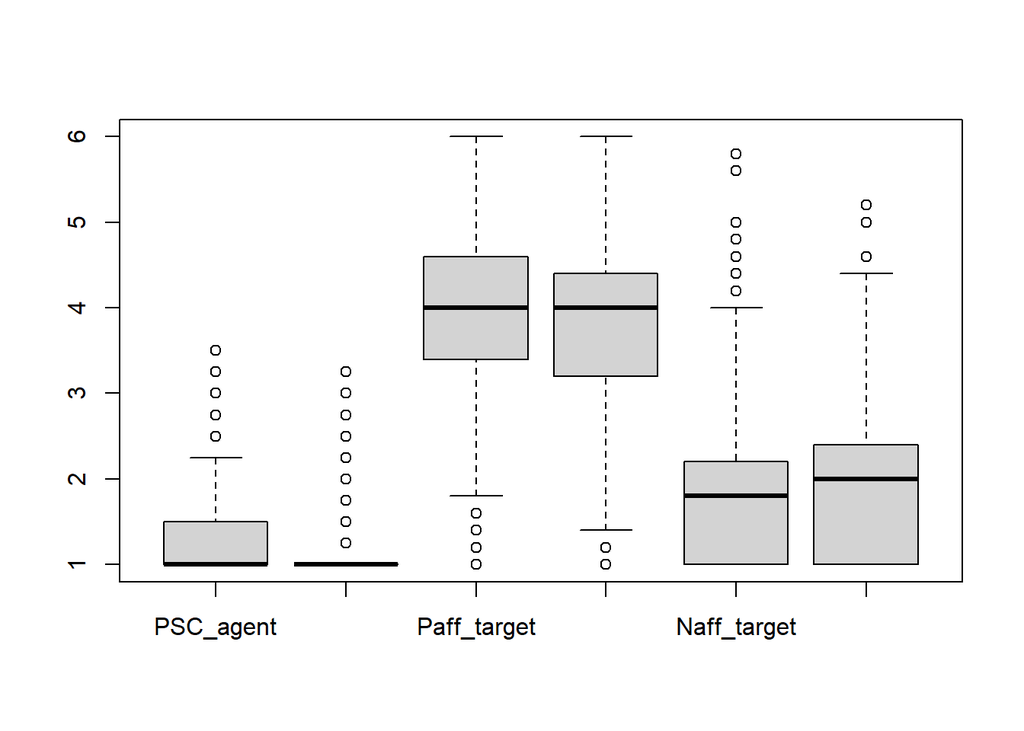

```r
scales <- c("PSC_agent", "NSC_agent", "Paff_target", "Paff_agent", "Naff_target", "Naff_agent")
mvpa <- c("sbwmvpa01", "pbwmvpa01" )

boxplot(df[,scales])
```

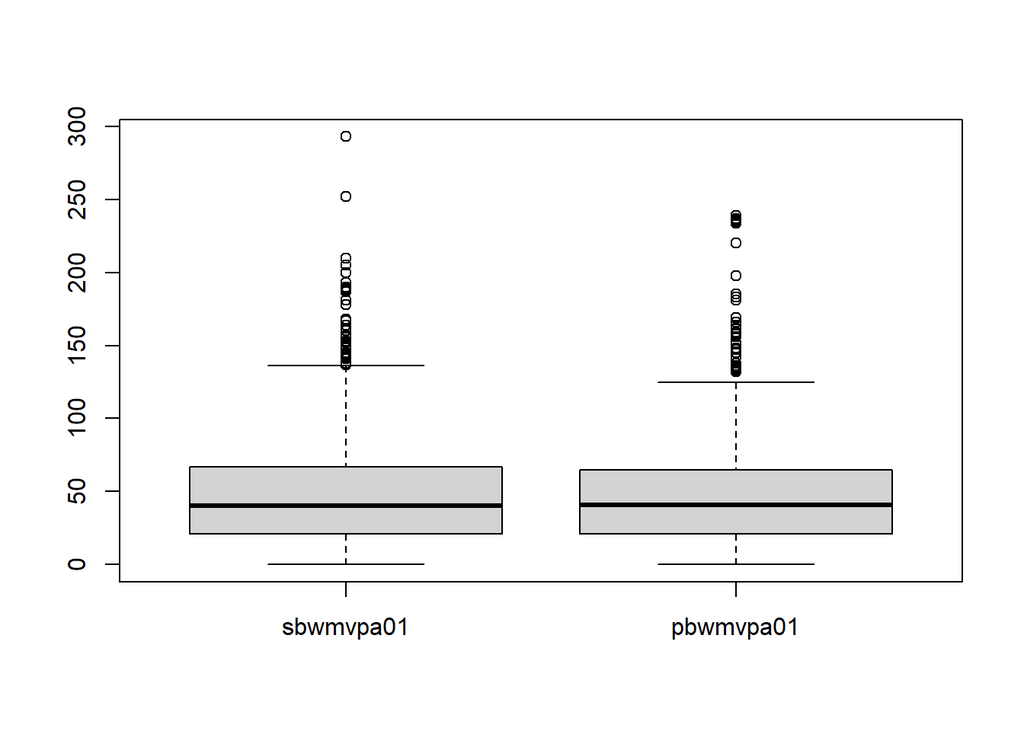

```r
boxplot(df[,mvpa])
```

### Histograms outcomes

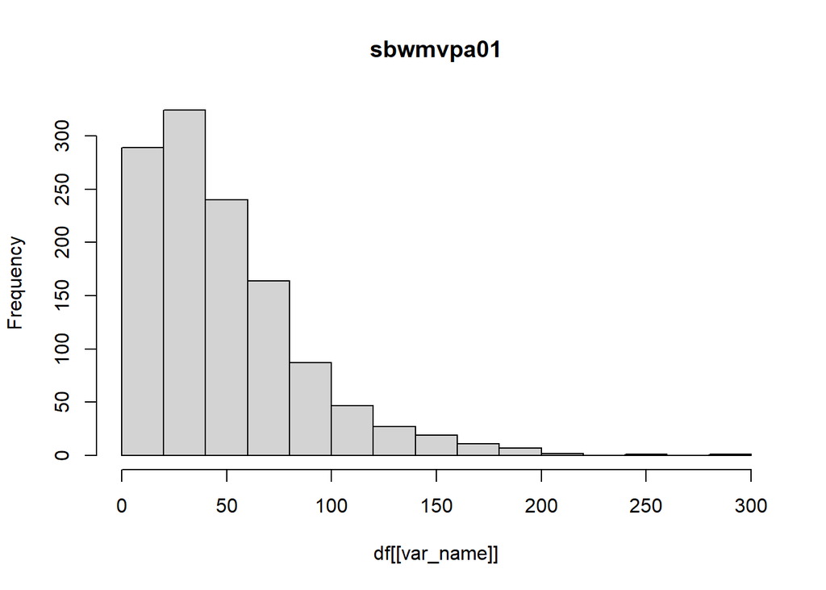

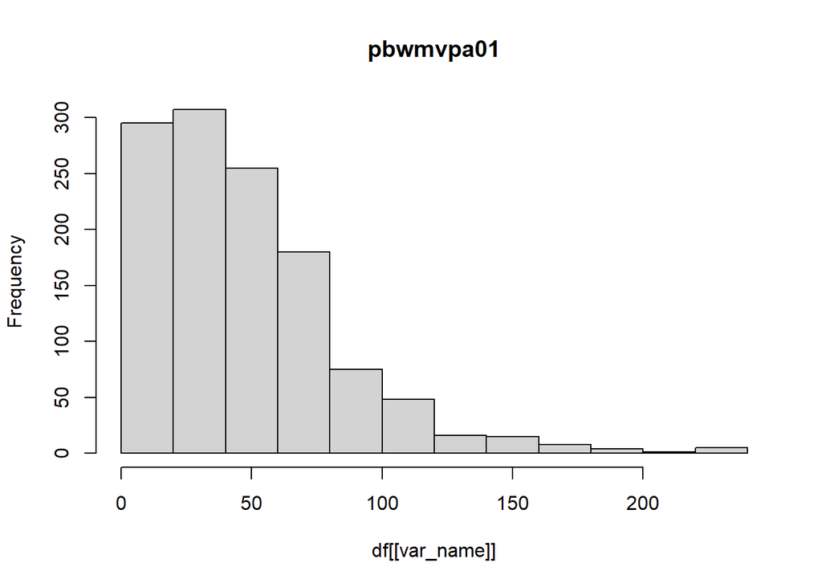

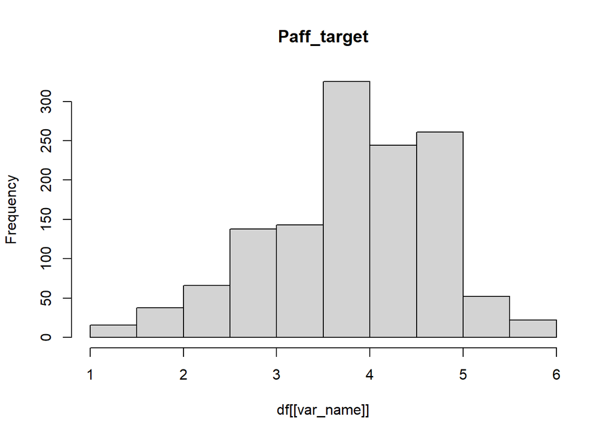

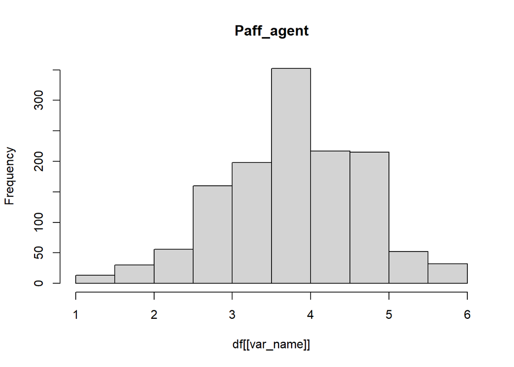

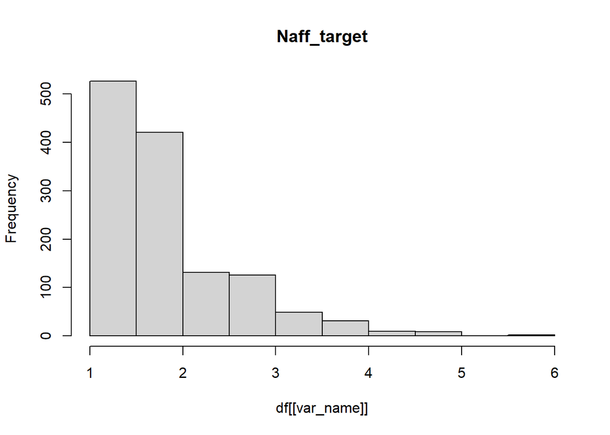

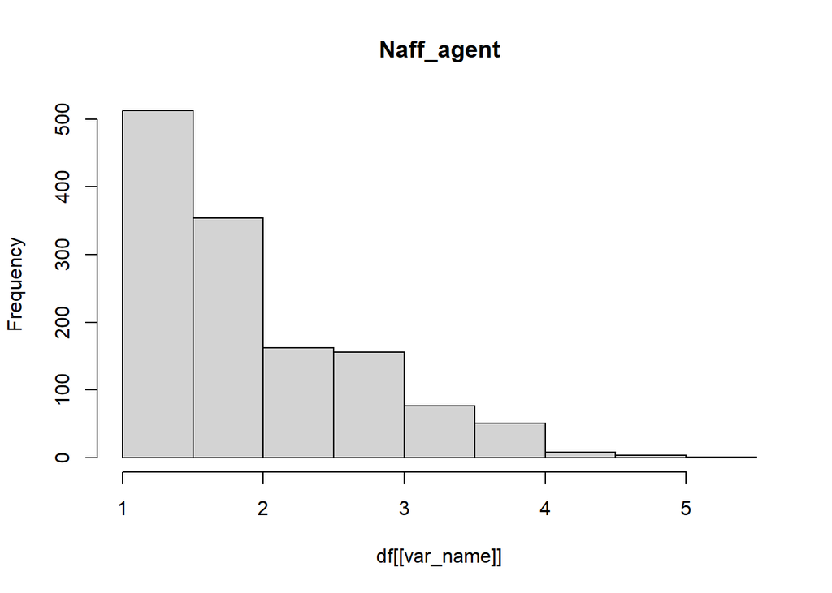

```r
var_names <- c("sbwmvpa01", "pbwmvpa01", "Paff_target", "Paff_agent", "Naff_target", "Naff_agent")

for (var_name in var_names) {
  hist(df[[var_name]], main=var_name)
}
```

### Histograms predictors

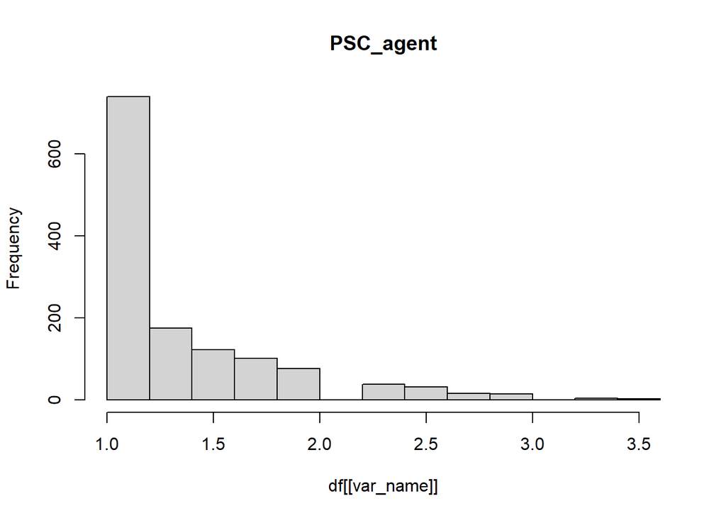

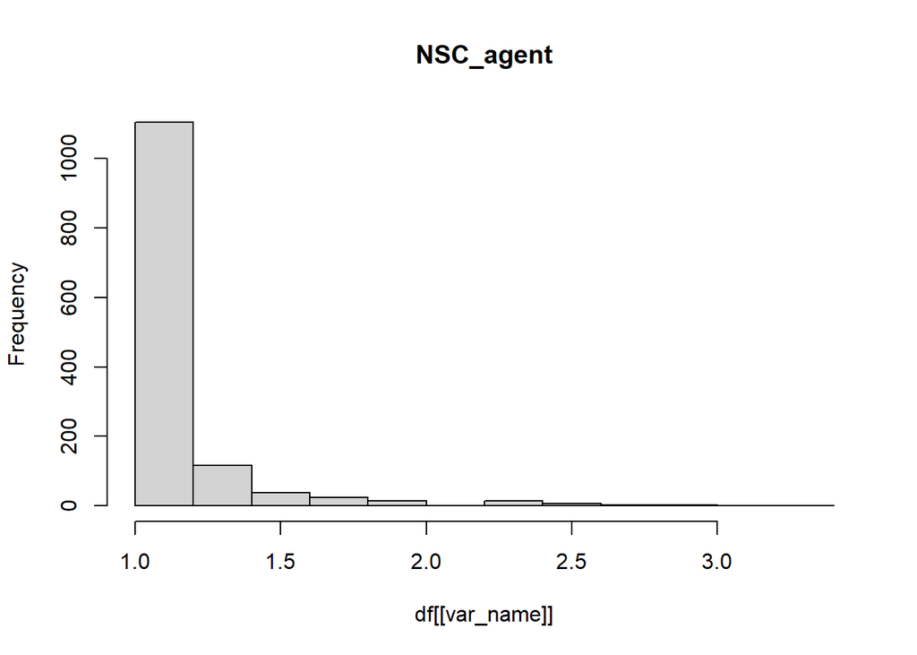

```r
var_names <- c("PSC_agent", "NSC_agent")

for (var_name in var_names) {
  hist(df[[var_name]], main=var_name)
}
```

## Correlations (within- and between person)

The package wbCorr and it’s code is available on Github: https://github.com/Pascal-Kueng/wbCorr

```r
wbCorrObject <- wbCorr(df_cors, df$CoupleID)
wbCorrObject_small <- wbCorr(df_cors_small, df$CoupleID)

cor_matrix <- summary(wbCorrObject, which = 'wb')
cor_matrix_small <- summary(wbCorrObject_small, 'wb')

wbCorr::to_excel(cor_matrix, "o2_1_CorrelationMatricesFull.xlsx")
wbCorr::to_excel(cor_matrix_small, "o2_2_CorrelationMatricesSmall.xlsx")

cor_matrix
```

```
## $merged_wb
##                                                    Exerted persuasion
## Exerted persuasion                                             [0.53]
## Exerted pressure                                              0.61***
## Positive affect agent                                            0.07
## Positive affect target                                           0.04
## Negative affect agent                                           0.21*
## Negative affect target                                          -0.08
## MVPA agent (in minutes)                                          0.05
## MVPA target (in minutes)                                         0.06
## Provided support agent                                        0.55***
## Provided support target                                        0.32**
## Wear time agent (in minutes)                                    -0.11
## Wear time target (in minutes)                                   -0.08
## Time spent together (in minutes)                                 0.00
## Previous day's intention to be active today agent                0.13
## Previous day's intention to be active today target             0.30**
## Previous day's self-efficacy for today agent                     0.10
## Previous day's self-efficacy for today target                  0.30**
## Risk perception of not engaging in MVPA agent                    0.08
## Risk perception of not engaging in MVPA target                   0.04
## Perceived benefits of MVPA agent                                 0.06
## Perceived benefits of MVPA target                                0.19
## Day                                                                NA
## Weekend (no = 0; yes = 1)                                        0.18
## Intervention group (no = 0; yes = 1)                            -0.03
## Relationship length (years)                                     -0.16
## Age target (years)                                               0.00
## Age agent (years)                                                0.01
## BMI target (kg/m2)                                               0.01
## BMI agent (kg/m2)                                               -0.07
## Gender target (female = 0; male = 1)                            -0.08
## Gender agent (female = 0; male = 1)                              0.08
## Kids (no = 0; yes = 1)                                         -0.20*
##                                                    Exerted pressure
## Exerted persuasion                                          0.36***
## Exerted pressure                                             [0.48]
## Positive affect agent                                          0.05
## Positive affect target                                        -0.08
## Negative affect agent                                          0.13
```

[output cut: 1005 more lines]

```
## Perceived benefits of MVPA target                                      NA
## Day                                                                    NA
## Weekend (no = 0; yes = 1)                                              NA
## Intervention group (no = 0; yes = 1)                                   NA
## Relationship length (years)                                            NA
## Age target (years)                                                     NA
## Age agent (years)                                                      NA
## BMI target (kg/m2)                                                     NA
## BMI agent (kg/m2)                                                      NA
## Gender target (female = 0; male = 1)                                   NA
## Gender agent (female = 0; male = 1)                                    NA
## Kids (no = 0; yes = 1)                                             [1.00]
##
## $note
## [1] "***p < 0.001, **p < 0.01, *p < 0.05"
```

```r
cor_matrix_small
```

```
## $merged_wb
##                                  Persuasion agent Pressure agent
## Persuasion agent                           [0.53]        0.36***
## Pressure agent                            0.61***         [0.48]
## Positive affect agent                        0.07           0.05
## Positive affect target                       0.04          -0.08
## Negative affect agent                       0.21*           0.13
## Negative affect target                      -0.08           0.02
## MVPA agent (in minutes)                      0.05          0.20*
## MVPA target (in minutes)                     0.06           0.06
## Provided support agent                    0.55***          0.22*
## Provided support target                    0.32**           0.11
## Wear time agent (in minutes)                -0.11        -0.29**
## Wear time target (in minutes)               -0.08          -0.15
## Time spent together (in minutes)             0.00           0.03
## Day                                            NA             NA
## Weekend (no = 0; yes = 1)                    0.18          -0.03
##                                  Positive affect agent Positive affect target
## Persuasion agent                               0.17***                   0.02
## Pressure agent                                   -0.01                  -0.01
## Positive affect agent                           [0.55]                0.16***
## Positive affect target                           0.24*                 [0.63]
## Negative affect agent                          -0.29**                  -0.16
## Negative affect target                          -0.21*               -0.33***
## MVPA agent (in minutes)                           0.04                  -0.12
## MVPA target (in minutes)                          0.04                   0.01
## Provided support agent                           -0.03                  -0.12
## Provided support target                           0.08                  0.20*
## Wear time agent (in minutes)                     0.25*                 0.29**
## Wear time target (in minutes)                     0.10                0.38***
## Time spent together (in minutes)                  0.16                   0.09
## Day                                                 NA                     NA
## Weekend (no = 0; yes = 1)                         0.16                   0.19
##                                  Negative affect agent Negative affect target
## Persuasion agent                              -0.10***                  -0.03
## Pressure agent                                    0.04                  -0.04
## Positive affect agent                         -0.35***                 -0.07*
## Positive affect target                        -0.12***               -0.32***
## Negative affect agent                           [0.60]                0.19***
## Negative affect target                           0.22*                 [0.66]
```

[output cut: 109 more lines]

```
## Positive affect target                                0.05
## Negative affect agent                             -0.15***
## Negative affect target                            -0.11***
## MVPA agent (in minutes)                               0.01
## MVPA target (in minutes)                           -0.09**
## Provided support agent                             0.16***
## Provided support target                            0.19***
## Wear time agent (in minutes)                      -0.24***
## Wear time target (in minutes)                     -0.25***
## Time spent together (in minutes)                   0.48***
## Day                                                 -0.06*
## Weekend (no = 0; yes = 1)                           [0.00]
##
## $note
## [1] "***p < 0.001, **p < 0.01, *p < 0.05"
```

## Descriptives

```r
# Stats for all Vars with the full DF
vars_stats <- setdiff(vars_b, c("sb0sex01", "pb0sex01", "sb0kih01"))

as.data.frame(report_table(df[,vars_stats]))
```

|  | Variable | n_Obs | Mean | SD | Median | MAD | Min | Max | Skewness | Kurtosis | percentage_Missing |
| --- | --- | --- | --- | --- | --- | --- | --- | --- | --- | --- | --- |
| 4 | PSC_agent | 1386 | 1.3245283 | 0.4896611 | NA | 0.000000 | 1.000000 | 3.50000 | 1.7147495 | 2.5868786 | 4.401154 |
| 3 | NSC_agent | 1386 | 1.0913208 | 0.2674431 | NA | 0.000000 | 1.000000 | 3.25000 | 3.9598894 | 17.8803644 | 4.401154 |
| 14 | Paff_agent | 1386 | 3.8297358 | 0.8945574 | NA | 0.889560 | 1.000000 | 6.00000 | -0.2519790 | 0.1288858 | 4.401154 |
| 16 | Paff_target | 1386 | 3.8798467 | 0.9181703 | NA | 0.889560 | 1.000000 | 6.00000 | -0.5435790 | 0.1458711 | 5.844156 |
| 6 | Naff_agent | 1386 | 1.9089811 | 0.8354057 | NA | 1.186080 | 1.000000 | 5.20000 | 0.7543294 | -0.0342868 | 4.401154 |
| 5 | Naff_target | 1386 | 1.8275862 | 0.7954081 | NA | 0.889560 | 1.000000 | 5.80000 | 1.1465004 | 1.6045938 | 5.844156 |
| 28 | pbwmvpa01 | 1386 | 47.4722911 | 36.3134501 | NA | 32.617200 | 0.000000 | 239.00000 | 1.5727239 | 3.9479911 | 12.770563 |
| 29 | sbwmvpa01 | 1386 | 48.7621001 | 37.9352898 | NA | 31.134600 | 0.000000 | 293.00000 | 1.5184971 | 3.4646589 | 12.049062 |
| 9 | Sup_agent | 1386 | 2.5271698 | 1.3117013 | NA | 1.482600 | 1.000000 | 6.00000 | 0.5058675 | -0.7302349 | 4.401154 |
| 7 | Sup_target | 1386 | 2.2306513 | 1.2507893 | NA | 1.482600 | 1.000000 | 6.00000 | 0.8094654 | -0.3463761 | 5.844156 |
| 21 | pbwwear | 1386 | 14.1049862 | 3.1993645 | NA | 2.248610 | 0.050000 | 24.00000 | -1.5197086 | 4.2668266 | 4.256854 |
| 22 | sbwwear | 1386 | 14.3150290 | 3.3327135 | NA | 2.125060 | 0.050000 | 24.00000 | -1.6797241 | 4.6745854 | 4.545454 |
| 20 | time_spent | 1386 | 10.3860599 | 8.8326580 | NA | 7.042350 | -174.000000 | 31.50000 | -6.8846666 | 148.3397404 | 8.441558 |
| 13 | intention_agent_lagged | 1386 | 3.7796226 | 1.3882464 | NA | 1.482600 | 1.000000 | 6.00000 | -0.5668242 | -0.5763436 | 4.401154 |
| 15 | intention_target_lagged | 1386 | 3.8404908 | 1.3803861 | NA | 1.482600 | 1.000000 | 6.00000 | -0.5115753 | -0.6245229 | 5.916306 |
| 11 | self_efficacy_agent_lagged | 1386 | 3.6437736 | 1.3931916 | NA | 1.482600 | 1.000000 | 6.00000 | -0.4295911 | -0.7545263 | 4.401154 |
| 12 | self_efficacy_target_lagged | 1386 | 3.6894172 | 1.4307268 | NA | 1.482600 | 1.000000 | 6.00000 | -0.4169754 | -0.8814103 | 5.916306 |
| 10 | risk_perception_agent | 1386 | 2.5396226 | 1.2940632 | NA | 1.482600 | 1.000000 | 6.00000 | 0.6413973 | -0.1944549 | 4.401154 |
| 8 | risk_perception_target | 1386 | 2.4099617 | 1.2604382 | NA | 1.482600 | 1.000000 | 6.00000 | 0.6570879 | -0.3490151 | 5.844156 |
| 17 | perceived_benfeits_agent | 1386 | 4.2203774 | 1.4252921 | NA | 1.482600 | 1.000000 | 6.00000 | -0.8935785 | -0.1405395 | 4.401154 |
| 18 | perceived_benfeits_target | 1386 | 4.2766284 | 1.4085457 | NA | 1.482600 | 1.000000 | 6.00000 | -0.8991719 | -0.0594320 | 5.844156 |
| 19 | sbyday | 1386 | 6.5000000 | 4.0325839 | 6.50000 | 5.189100 | 0.000000 | 13.00000 | 0.0000000 | -1.2123510 | 0.000000 |
| 1 | weeknd2 | 1386 | 0.2857143 | 0.4519170 | 0.00000 | 0.000000 | 0.000000 | 1.00000 | 0.9497114 | -1.0996371 | 0.000000 |
| 2 | EG | 1386 | 0.5050505 | 0.5001550 | 1.00000 | 0.000000 | 0.000000 | 1.00000 | -0.0202249 | -2.0024826 | 0.000000 |
| 23 | reldur | 1386 | 19.0892256 | 14.2951993 | 14.00000 | 13.714050 | 1.083333 | 52.00000 | 0.7076798 | -0.7328748 | 0.000000 |
| 27 | sage | 1386 | 46.3131313 | 13.6754042 | 45.00000 | 17.791200 | 22.000000 | 72.00000 | 0.1487367 | -1.1150532 | 0.000000 |
| 26 | page | 1386 | 46.2929293 | 13.7245484 | 45.00000 | 16.308600 | 23.000000 | 75.00000 | 0.3004480 | -0.9586772 | 0.000000 |
| 24 | sbmi | 1386 | 30.9374662 | 5.6003420 | 29.55017 | 3.321328 | 24.981738 | 61.72840 | 2.4293276 | 8.6506763 | 0.000000 |
| 25 | pbmi | 1386 | 31.2379254 | 4.1765410 | 30.57008 | 3.809801 | 25.176321 | 49.60938 | 1.3934164 | 3.4032760 | 0.000000 |

```r
as.data.frame(report_table(df$reldur))
```

| Mean | SD | Median | MAD | Min | Max | n_Obs | Skewness | Kurtosis | percentage_Missing |
| --- | --- | --- | --- | --- | --- | --- | --- | --- | --- |
| 19.08923 | 14.2952 | 14 | 13.71405 | 1.083333 | 52 | 1386 | 0.7076798 | -0.7328748 | 0 |

# Save datasets

```r
# Only save the variables we need for furhter analyses for data protection reasons.

# Define the list of variables to keep
variables_to_keep <- c(
  'ppysko06', 'ppysko09', 'ppysko21', 'ppysko25',
  'ppysko03', 'ppysko11', 'ppysko26', 'ppysko29',

  'CoupleID', 'PSC_agent', 'NSC_agent', 'PSC_agent_cw', 'NSC_agent_cw', 'sbyday', 'weeknd2',
  'PSC_agent_cb', 'NSC_agent_cb', 'sbwmvpa01', 'sbwwear_cw', 'sbwwear_cb',
  'sbwwear', 'pbwwear',
  'pbwmvpa01', 'pbwwear_cw', 'pbwwear_cb', 'Sup_agent_cw', 'Sup_target_cw',
  'time_spent_cw', 'intention_agent_lagged_cw', 'intention_target_lagged_cw',
  'self_efficacy_agent_lagged_cw', 'self_efficacy_target_lagged_cw',
  'plan_agent_lagged_cw', 'plan_target_lagged_cw', 'risk_perception_agent_cw',
  'risk_perception_target_cw', 'perceived_benfeits_agent_cw',
  'perceived_benfeits_target_cw', 'Sup_agent_cb', 'Sup_target_cb',
  'time_spent_cb', 'intention_agent_lagged_cb', 'intention_target_lagged_cb',
  'self_efficacy_agent_lagged_cb', 'self_efficacy_target_lagged_cb',
  'plan_agent_lagged_cb', 'plan_target_lagged_cb', 'risk_perception_agent_cb',
  'risk_perception_target_cb', 'perceived_benfeits_agent_cb',
  'perceived_benfeits_target_cb', 'reldur_cb', 'page', 'sage', 'pbmi', 'sbmi',
  'sb0kih01', 'pb0kih01', 'sb0sex01', 'pb0sex01', 'group', 'Paff_target', 'Naff_target',
  'Paff_agent', 'Naff_agent'
)





df_og <- df
# Subset the dataframe
df_subset <- df_og %>% select(all_of(variables_to_keep))

# Save the subset to an RDS file for OSF
saveRDS(df_subset, file = 'DataSet_Subset.rds')
```

# References (Packages) and System information

```r
report::report_system()
```

```
## Analyses were conducted using the R Statistical language (version 4.4.1; R Core
## Team, 2024) on Windows 11 x64 (build 22635)
```

```r
report::report_packages()
```

- lme4 (version 1.1.35.5; Bates D et al., 2015)
- Matrix (version 1.7.0; Bates D et al., 2024)
- effectsize (version 0.8.9; Ben-Shachar MS et al., 2020)
- broom.mixed (version 0.2.9.5; Bolker B, Robinson D, 2024)
- glmmTMB (version 1.1.10; Brooks ME et al., 2017)
- basicPlotteR (version 0.0.0.9000; Crispell J, 2024)
- Rcpp (version 1.0.13; Eddelbuettel D et al., 2024)
- ggResidpanel (version 0.3.0; Goode K, Rey K, 2019)
- lubridate (version 1.9.3; Grolemund G, Wickham H, 2011)
- Hmisc (version 5.1.3; Harrell Jr F, 2024)
- DHARMa (version 0.4.6; Hartig F, 2022)
- wbCorr (version 0.1.22; Küng P, 2023)
- ggeffects (version 1.7.1; Lüdecke D, 2018)
- parameters (version 0.22.2; Lüdecke D et al., 2020)
- performance (version 0.12.3; Lüdecke D et al., 2021)
- easystats (version 0.7.3; Lüdecke D et al., 2022)
- see (version 0.9.0; Lüdecke D et al., 2021)
- insight (version 0.20.4; Lüdecke D et al., 2019)
- bayestestR (version 0.14.0; Makowski D et al., 2019)
- modelbased (version 0.8.8; Makowski D et al., 2020)
- report (version 0.5.9; Makowski D et al., 2023)
- correlation (version 0.8.5; Makowski D et al., 2022)
- tibble (version 3.2.1; Müller K, Wickham H, 2023)
- datawizard (version 0.12.3; Patil I et al., 2022)
- nlme (version 3.1.164; Pinheiro J et al., 2023)
- R (version 4.4.1; R Core Team, 2024)
- lavaan (version 0.6.18; Rosseel Y, 2012)
- MASS (version 7.3.60.2; Venables WN, Ripley BD, 2002)
- bmlm (version 1.3.15; Vuorre M, Bolger N, 2018)
- ggplot2 (version 3.5.1; Wickham H, 2016)
- forcats (version 1.0.0; Wickham H, 2023)
- stringr (version 1.5.1; Wickham H, 2023)
- tidyverse (version 2.0.0; Wickham H et al., 2019)
- usethis (version 3.0.0; Wickham H et al., 2024)
- dplyr (version 1.1.4; Wickham H et al., 2023)
- purrr (version 1.0.2; Wickham H, Henry L, 2023)
- readr (version 2.1.5; Wickham H et al., 2024)
- devtools (version 2.4.5; Wickham H et al., 2022)
- haven (version 2.5.4; Wickham H et al., 2023)
- scales (version 1.3.0; Wickham H et al., 2023)
- tidyr (version 1.3.1; Wickham H et al., 2024)
- cowplot (version 1.1.3; Wilke C, 2024)
- psych (version 2.4.6.26; William Revelle, 2024)
- misty (version 0.6.7; Yanagida T, 2024)

```r
report::cite_packages()
```

- Bates D, Mächler M, Bolker B, Walker S (2015). “Fitting Linear Mixed-Effects Models Using lme4.” *Journal of Statistical Software*, *67*(1), 1-48. doi:10.18637/jss.v067.i01 https://doi.org/10.18637/jss.v067.i01.
- Bates D, Maechler M, Jagan M (2024). *Matrix: Sparse and Dense Matrix Classes and Methods*. R package version 1.7-0, https://CRAN.R-project.org/package=Matrix.
- Ben-Shachar MS, Lüdecke D, Makowski D (2020). “effectsize: Estimation of Effect Size Indices and Standardized Parameters.” *Journal of Open Source Software*, *5*(56), 2815. doi:10.21105/joss.02815 https://doi.org/10.21105/joss.02815, https://doi.org/10.21105/joss.02815.
- Bolker B, Robinson D (2024). *broom.mixed: Tidying Methods for Mixed Models*. R package version 0.2.9.5, https://CRAN.R-project.org/package=broom.mixed.
- Brooks ME, Kristensen K, van Benthem KJ, Magnusson A, Berg CW, Nielsen A, Skaug HJ, Maechler M, Bolker BM (2017). “glmmTMB Balances Speed and Flexibility Among Packages for Zero-inflated Generalized Linear Mixed Modeling.” *The R Journal*, *9*(2), 378-400. doi:10.32614/RJ-2017-066 https://doi.org/10.32614/RJ-2017-066.
- Crispell J (2024). *basicPlotteR: A collection of functions to help with base R plotting*. R package version 0.0.0.9000, commit 4628140c8eac2adac70d85632b9d0966a374e4bf, https://github.com/JosephCrispell/basicPlotteR.
- Eddelbuettel D, Francois R, Allaire J, Ushey K, Kou Q, Russell N, Ucar I, Bates D, Chambers J (2024). *Rcpp: Seamless R and C++ Integration*. R package version 1.0.13, https://CRAN.R-project.org/package=Rcpp. Eddelbuettel D, François R (2011). “Rcpp: Seamless R and C++ Integration.” *Journal of Statistical Software*, *40*(8), 1-18. doi:10.18637/jss.v040.i08 https://doi.org/10.18637/jss.v040.i08. Eddelbuettel D (2013). *Seamless R and C++ Integration with Rcpp*. Springer, New York. doi:10.1007/978-1-4614-6868-4 https://doi.org/10.1007/978-1-4614-6868-4, ISBN 978-1-4614-6867-7. Eddelbuettel D, Balamuta J (2018). “Extending R with C++: A Brief Introduction to Rcpp.” *The American Statistician*, *72*(1), 28-36. doi:10.1080/00031305.2017.1375990 https://doi.org/10.1080/00031305.2017.1375990.
- Goode K, Rey K (2019). *ggResidpanel: Panels and Interactive Versions of Diagnostic Plots using ‘ggplot2’*. R package version 0.3.0, https://CRAN.R-project.org/package=ggResidpanel.
- Grolemund G, Wickham H (2011). “Dates and Times Made Easy with lubridate.” *Journal of Statistical Software*, *40*(3), 1-25. https://www.jstatsoft.org/v40/i03/.
- Harrell Jr F (2024). *Hmisc: Harrell Miscellaneous*. R package version 5.1-3, https://CRAN.R-project.org/package=Hmisc.
- Hartig F (2022). *DHARMa: Residual Diagnostics for Hierarchical (Multi-Level / Mixed) Regression Models*. R package version 0.4.6, https://CRAN.R-project.org/package=DHARMa.
- Küng P (2023). *wbCorr: Bivariate Within- and Between-Cluster Correlations*. University of Zürich. R package version 0.1.22. https://github.com/Pascal-Kueng/wbCorr.
- Lüdecke D (2018). “ggeffects: Tidy Data Frames of Marginal Effects from Regression Models.” *Journal of Open Source Software*, *3*(26), 772. doi:10.21105/joss.00772 https://doi.org/10.21105/joss.00772.
- Lüdecke D, Ben-Shachar M, Patil I, Makowski D (2020). “Extracting, Computing and Exploring the Parameters of Statistical Models using R.” *Journal of Open Source Software*, *5*(53), 2445. doi:10.21105/joss.02445 https://doi.org/10.21105/joss.02445.
- Lüdecke D, Ben-Shachar M, Patil I, Waggoner P, Makowski D (2021). “performance: An R Package for Assessment, Comparison and Testing of Statistical Models.” *Journal of Open Source Software*, *6*(60), 3139. doi:10.21105/joss.03139 https://doi.org/10.21105/joss.03139.
- Lüdecke D, Ben-Shachar M, Patil I, Wiernik B, Bacher E, Thériault R, Makowski D (2022). “easystats: Framework for Easy Statistical Modeling, Visualization, and Reporting.” *CRAN*. doi:10.32614/CRAN.package.easystats https://doi.org/10.32614/CRAN.package.easystats, R package, https://easystats.github.io/easystats/.
- Lüdecke D, Patil I, Ben-Shachar M, Wiernik B, Waggoner P, Makowski D (2021). “see: An R Package for Visualizing Statistical Models.” *Journal of Open Source Software*, *6*(64), 3393. doi:10.21105/joss.03393 https://doi.org/10.21105/joss.03393.
- Lüdecke D, Waggoner P, Makowski D (2019). “insight: A Unified Interface to Access Information from Model Objects in R.” *Journal of Open Source Software*, *4*(38), 1412. doi:10.21105/joss.01412 https://doi.org/10.21105/joss.01412.
- Makowski D, Ben-Shachar M, Lüdecke D (2019). “bayestestR: Describing Effects and their Uncertainty, Existence and Significance within the Bayesian Framework.” *Journal of Open Source Software*, *4*(40), 1541. doi:10.21105/joss.01541 https://doi.org/10.21105/joss.01541, https://joss.theoj.org/papers/10.21105/joss.01541.
- Makowski D, Ben-Shachar M, Patil I, Lüdecke D (2020). “Estimation of Model-Based Predictions, Contrasts and Means.” *CRAN*. https://github.com/easystats/modelbased.
- Makowski D, Lüdecke D, Patil I, Thériault R, Ben-Shachar M, Wiernik B (2023). “Automated Results Reporting as a Practical Tool to Improve Reproducibility and Methodological Best Practices Adoption.” *CRAN*. https://easystats.github.io/report/.
- Makowski D, Wiernik B, Patil I, Lüdecke D, Ben-Shachar M (2022). “correlation: Methods for Correlation Analysis.” Version 0.8.3, https://CRAN.R-project.org/package=correlation. Makowski D, Ben-Shachar M, Patil I, Lüdecke D (2020). “Methods and Algorithms for Correlation Analysis in R.” *Journal of Open Source Software*, *5*(51), 2306. doi:10.21105/joss.02306 https://doi.org/10.21105/joss.02306, https://joss.theoj.org/papers/10.21105/joss.02306.
- Müller K, Wickham H (2023). *tibble: Simple Data Frames*. R package version 3.2.1, https://CRAN.R-project.org/package=tibble.
- Patil I, Makowski D, Ben-Shachar M, Wiernik B, Bacher E, Lüdecke D (2022). “datawizard: An R Package for Easy Data Preparation and Statistical Transformations.” *Journal of Open Source Software*, *7*(78), 4684. doi:10.21105/joss.04684 https://doi.org/10.21105/joss.04684.
- Pinheiro J, Bates D, R Core Team (2023). *nlme: Linear and Nonlinear Mixed Effects Models*. R package version 3.1-164, https://CRAN.R-project.org/package=nlme. Pinheiro JC, Bates DM (2000). *Mixed-Effects Models in S and S-PLUS*. Springer, New York. doi:10.1007/b98882 https://doi.org/10.1007/b98882.
- R Core Team (2024). *R: A Language and Environment for Statistical Computing*. R Foundation for Statistical Computing, Vienna, Austria. https://www.R-project.org/.
- Rosseel Y (2012). “lavaan: An R Package for Structural Equation Modeling.” *Journal of Statistical Software*, *48*(2), 1-36. doi:10.18637/jss.v048.i02 https://doi.org/10.18637/jss.v048.i02.
- Venables WN, Ripley BD (2002). *Modern Applied Statistics with S*, Fourth edition. Springer, New York. ISBN 0-387-95457-0, https://www.stats.ox.ac.uk/pub/MASS4/.
- Vuorre M, Bolger N (2018). “Within-subject mediation analysis for experimental data in cognitive psychology and neuroscience.” *Behavior Research Methods*. doi:10.3758/s13428-017-0980-9 https://doi.org/10.3758/s13428-017-0980-9. Vuorre M (2023). *bmlm: Bayesian Multilevel Mediation*. R package version 1.3.15, https://CRAN.R-project.org/package=bmlm.
- Wickham H (2016). *ggplot2: Elegant Graphics for Data Analysis*. Springer-Verlag New York. ISBN 978-3-319-24277-4, https://ggplot2.tidyverse.org.
- Wickham H (2023). *forcats: Tools for Working with Categorical Variables (Factors)*. R package version 1.0.0, https://CRAN.R-project.org/package=forcats.
- Wickham H (2023). *stringr: Simple, Consistent Wrappers for Common String Operations*. R package version 1.5.1, https://CRAN.R-project.org/package=stringr.
- Wickham H, Averick M, Bryan J, Chang W, McGowan LD, François R, Grolemund G, Hayes A, Henry L, Hester J, Kuhn M, Pedersen TL, Miller E, Bache SM, Müller K, Ooms J, Robinson D, Seidel DP, Spinu V, Takahashi K, Vaughan D, Wilke C, Woo K, Yutani H (2019). “Welcome to the tidyverse.” *Journal of Open Source Software*, *4*(43), 1686. doi:10.21105/joss.01686 https://doi.org/10.21105/joss.01686.
- Wickham H, Bryan J, Barrett M, Teucher A (2024). *usethis: Automate Package and Project Setup*. R package version 3.0.0, https://CRAN.R-project.org/package=usethis.
- Wickham H, François R, Henry L, Müller K, Vaughan D (2023). *dplyr: A Grammar of Data Manipulation*. R package version 1.1.4, https://CRAN.R-project.org/package=dplyr.
- Wickham H, Henry L (2023). *purrr: Functional Programming Tools*. R package version 1.0.2, https://CRAN.R-project.org/package=purrr.
- Wickham H, Hester J, Bryan J (2024). *readr: Read Rectangular Text Data*. R package version 2.1.5, https://CRAN.R-project.org/package=readr.
- Wickham H, Hester J, Chang W, Bryan J (2022). *devtools: Tools to Make Developing R Packages Easier*. R package version 2.4.5, https://CRAN.R-project.org/package=devtools.
- Wickham H, Miller E, Smith D (2023). *haven: Import and Export ‘SPSS’, ‘Stata’ and ‘SAS’ Files*. R package version 2.5.4, https://CRAN.R-project.org/package=haven.
- Wickham H, Pedersen T, Seidel D (2023). *scales: Scale Functions for Visualization*. R package version 1.3.0, https://CRAN.R-project.org/package=scales.
- Wickham H, Vaughan D, Girlich M (2024). *tidyr: Tidy Messy Data*. R package version 1.3.1, https://CRAN.R-project.org/package=tidyr.
- Wilke C (2024). *cowplot: Streamlined Plot Theme and Plot Annotations for ‘ggplot2’*. R package version 1.1.3, https://CRAN.R-project.org/package=cowplot.
- William Revelle (2024). *psych: Procedures for Psychological, Psychometric, and Personality Research*. Northwestern University, Evanston, Illinois. R package version 2.4.6, https://CRAN.R-project.org/package=psych.
- Yanagida T (2024). *misty: Miscellaneous Functions ‘T. Yanagida’*. R package version 0.6.7, https://CRAN.R-project.org/package=misty.